# O Canada

Quick and dirty Canadian map example

Kieran Healy http://kieranhealy.org (Duke University)http://duke.edu  
2018-12-09

Mapping data (and, more importantly, converting map data into a format that we can tidily use) requires a bit more heavy lifting behind the scenes than the core `tidyverse` libraries provide. Start by installing the `sf` library, which will also bring a number of dependencies with it.

```r
install.packages("sf")
install.packages("rgdal")
install.packages("geojsonio")
install.packages("spdplyr")
install.packages("rmapshaper")
```

## Downloading and converting the map files for the first time

You won’t be able to run the code in this section until you have some raw shapefiles to work with. Get data from Statistics Canada: http://www12.statcan.gc.ca/census-recensement/2011/geo/bound-limit/bound-limit-2011-eng.cfm. From the linked page, choose as your options *ArcGIS .shp file*, then—for example—*Census divisions* and *cartographic boundaries*. You’ll then download a zip file. Expand this zip file into a directory in your working folder named ‘data’. Then import the shapefile as below. The `EVAL` option is set to `FALSE` on the chunks in this section, so they will not be evaluated if you run the document. (R will just skip to the next section below, instead.) To evaluate them, download the data as just described, and then remove the `eval = FALSE` option from each chunk.

```r
canada_raw <- readOGR(dsn = "data/gcd_000b11a_e", layer = "gcd_000b11a_e",
                      use_iconv=TRUE, encoding="CP1250")
```

Convert it to GeoJSON format and simplify the polygons. These steps will take a little while.

```r
canada_raw_json <- geojson_json(canada_raw)
canada_raw_sim <- ms_simplify(canada_raw_json)
```

Save the resulting GeoJSON file, which you can work with directly from here on

```r
geojson_write(canada_raw_sim, file = "data/canada_cd_sim.geojson")
```

## Working with the GeoJSON file in the tidyverse

Read the GeoJSON file back in as an `sf` object. The `.geojson` file is included in the repository, so you can load the libraries above and then start from here if you want.

```r
canada_cd <- st_read("data/canada_cd_sim.geojson", quiet = TRUE)

canada_cd
```

```
Simple feature collection with 293 features and 6 fields
geometry type:  MULTIPOLYGON
dimension:      XY
bbox:           xmin: -141.0181 ymin: 41.7297 xmax: -52.6194 ymax: 83.1355
epsg (SRID):    4269
proj4string:    +proj=longlat +ellps=GRS80 +towgs84=0,0,0,0,0,0,0 +no_defs
First 10 features:
   CDUID          CDNAME CDTYPE PRUID
1   4609 Division No.  9    CDR    46
2   5901   East Kootenay     RD    59
3   5933 Thompson-Nicola     RD    59
4   4816 Division No. 16    CDR    48
5   5919 Cowichan Valley     RD    59
6   4621 Division No. 21    CDR    46
7   4608 Division No.  8    CDR    46
```

[output cut: 25 more lines]

Transform the coordinates to a Lambert Conformal Conic Projection. (See https://www.statcan.gc.ca/pub/92-195-x/2011001/other-autre/mapproj-projcarte/m-c-eng.htm).

```r
canada_cd <- st_transform(canada_cd, crs = "+proj=lcc +lat_1=49 +lat_2=77 +lon_0=-91.52 +x_0=0 +y_0=0 +datum=NAD83 +units=m +no_defs")

canada_cd
```

```
Simple feature collection with 293 features and 6 fields
geometry type:  MULTIPOLYGON
dimension:      XY
bbox:           xmin: -2529065 ymin: 5816874 xmax: 2793734 ymax: 10396190
epsg (SRID):    NA
proj4string:    +proj=lcc +lat_1=49 +lat_2=77 +lat_0=0 +lon_0=-91.52 +x_0=0 +y_0=0 +ellps=GRS80 +towgs84=0,0,0,0,0,0,0 +units=m +no_defs
First 10 features:
   CDUID          CDNAME CDTYPE PRUID
1   4609 Division No.  9    CDR    46
2   5901   East Kootenay     RD    59
3   5933 Thompson-Nicola     RD    59
4   4816 Division No. 16    CDR    48
5   5919 Cowichan Valley     RD    59
6   4621 Division No. 21    CDR    46
7   4608 Division No.  8    CDR    46
```

[output cut: 25 more lines]

Make a vector of repeated colors—just to fill in the map, for decoration only, as I don’t have any Canadian data to merge in at present.

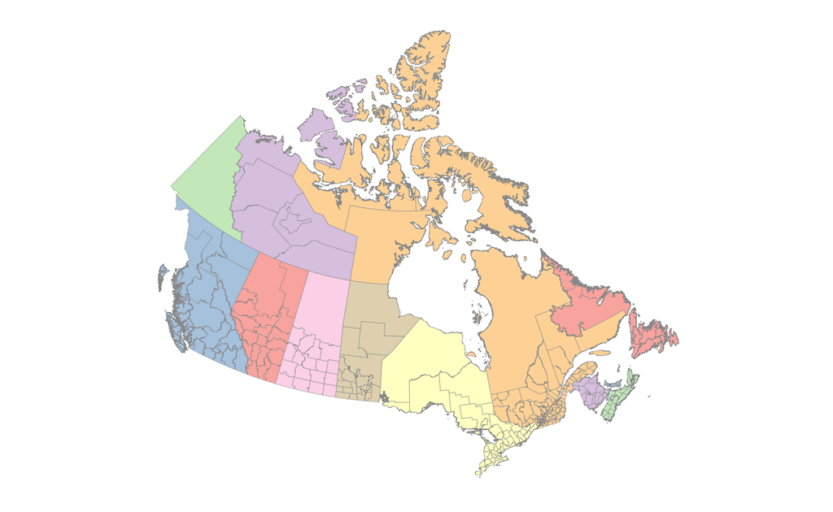

```r
map_colors <-  RColorBrewer::brewer.pal(8, "Pastel1")
map_colors <- rep(map_colors, 37)


## Draw the map
p <- ggplot(data = canada_cd,
            mapping = aes(fill = PRUID))
p_out <- p + geom_sf(color = "gray60",
                    size = 0.1) +
  scale_fill_manual(values = map_colors) +
  guides(fill = FALSE) +
  theme_map() +
  theme(panel.grid.major = element_line(color = "white"),
        legend.key = element_rect(color = "gray40", size = 0.1))

ggsave("figures/canada.pdf", p_out, height = 12, width = 15)

p_out
```